V The V Lab

# ggplot2 常用方法：从图形语法到出版级图表

一份可运行的中文实践教程

**适用对象**会运行基础 R 代码的学习者

**内容规模**15 章 · 20 幅实绘图表

**学习方式**按顺序学习或按主题查阅

# 1 阅读指南

这份教程面向已经会运行 R 代码、希望系统掌握 **ggplot2 常用方法**的读者。所有示例都使用 R 自带数据或 ggplot2 内置数据，不需要下载外部数据；代码块可以复制到 RStudio 中直接运行。

建议按下面的顺序思考一张图：

1. **数据（data）**：一行代表什么观察？变量类型是否正确？
2. **映射（mapping）**：哪些变量对应 x、y、颜色、填充、大小或分组？
3. **几何对象（geom）**：用点、线、柱、箱线还是密度表达？
4. **统计变换（stat）**：画原始值，还是计数、分箱、平滑或汇总值？
5. **位置与坐标（position / coord）**：堆叠、并列、抖动或缩放？
6. **标度（scale）**：颜色、刻度、标签和变换如何呈现？
7. **分面与主题（facet / theme）**：如何组织小图并完善版式？

核心心智模型：

```
ggplot(data, aes(…)) + geom_*() + scale_*() +
facet_*() + coord_*() + theme_*()
```

。每个 `+` 都是在图上增加或修改一层。

## 1.1 本教程使用的数据

| 数据 | 内容 | 常见用途 |
| --- | --- | --- |
| `mpg` | 1999 与 2008 年车型的油耗和规格 | 散点图、柱状图、分面 |
| `diamonds` | 约 5.4 万颗钻石的规格与价格 | 大数据、分布、对数标度 |
| `economics` | 美国月度经济指标 | 日期与时间序列 |
| `mtcars` | 32 辆汽车的性能 | 小型演示与建模 |

```r
dim(mpg)
```

```
#> [1] 234  11
```

```r
names(mpg)
```

```
#>  [1] "manufacturer" "model"        "displ"        "year"         "cyl"          "trans"
#>  [7] "drv"          "cty"          "hwy"          "fl"           "class"
```

```r
head(mpg, 3)
```

|  | manufacturer | model | displ | year | cyl | trans | drv | cty | hwy | fl | class |
| --- | --- | --- | --- | --- | --- | --- | --- | --- | --- | --- | --- |
| 1 | audi | a4 | 1.8 | 1999 | 4 | auto(l5) | f | 18 | 29 | p | compact |
| 2 | audi | a4 | 1.8 | 1999 | 4 | manual(m5) | f | 21 | 29 | p | compact |
| 3 | audi | a4 | 2.0 | 2008 | 4 | manual(m6) | f | 20 | 31 | p | compact |

# 2 图形语法基础

## 2.1 最小可用图形

`ggplot()` 创建画布，`aes()` 声明变量到视觉属性的映射，`geom_point()` 决定用点来画每一行数据。

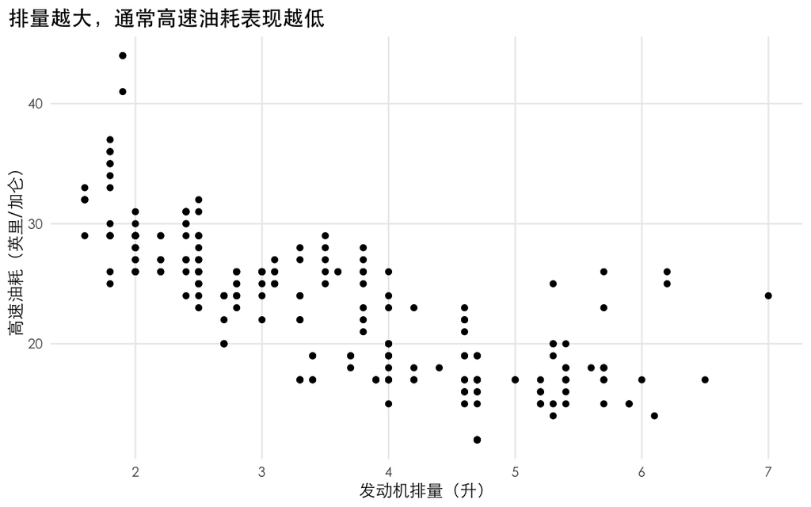

图 1：发动机排量与高速油耗的关系。

```r
ggplot(data = mpg, mapping = aes(x = displ, y = hwy)) +
  geom_point() +
  labs(
    title = "排量越大，通常高速油耗表现越低",
    x = "发动机排量（升）",
    y = "高速油耗（英里/加仑）"
  )
```

数据与映射也可分别放在图层里。全局 `aes()` 会被后续图层继承；局部 `aes()` 只影响所在图层。

## 2.2 映射与固定设置

- 写在 `aes()` **里面**：把变量映射到视觉属性，会产生数据驱动的变化和图例。
- 写在 `aes()` **外面**：把所有标记固定为同一个值，通常不产生图例。

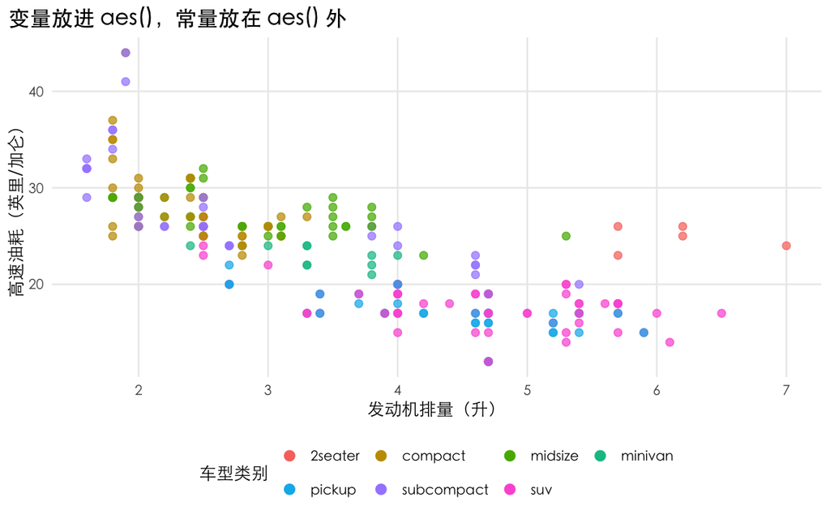

图 2：颜色映射车型类别，透明度和点大小固定。

```r
ggplot(mpg, aes(displ, hwy)) +
  geom_point(aes(color = class), alpha = 0.72, size = 2.2) +
  labs(
    title = "变量放进 aes()，常量放在 aes() 外",
    color = "车型类别",
    x = "发动机排量（升）",
    y = "高速油耗（英里/加仑）"
  ) +
  guides(color = guide_legend(nrow = 2, byrow = TRUE,
                              override.aes = list(alpha = 1, size = 3)))
```

下面是最常见的错误之一：`aes(color = "steelblue")` 会把字符串当成一个类别并创建图例，而不是把点设为蓝色。

```r
# 错误：把 "steelblue" 当作一个数据类别
ggplot(mpg, aes(displ, hwy)) + geom_point(aes(color = "steelblue"))

# 正确：所有点固定为蓝色
ggplot(mpg, aes(displ, hwy)) + geom_point(color = "steelblue")
```

## 2.3 全局映射、局部映射与分组

这里点的颜色映射到车型类别，而趋势线只按驱动方式 `drv` 分组。`group` 控制哪些观察属于同一条线；`show.legend = FALSE` 隐藏趋势线图例。

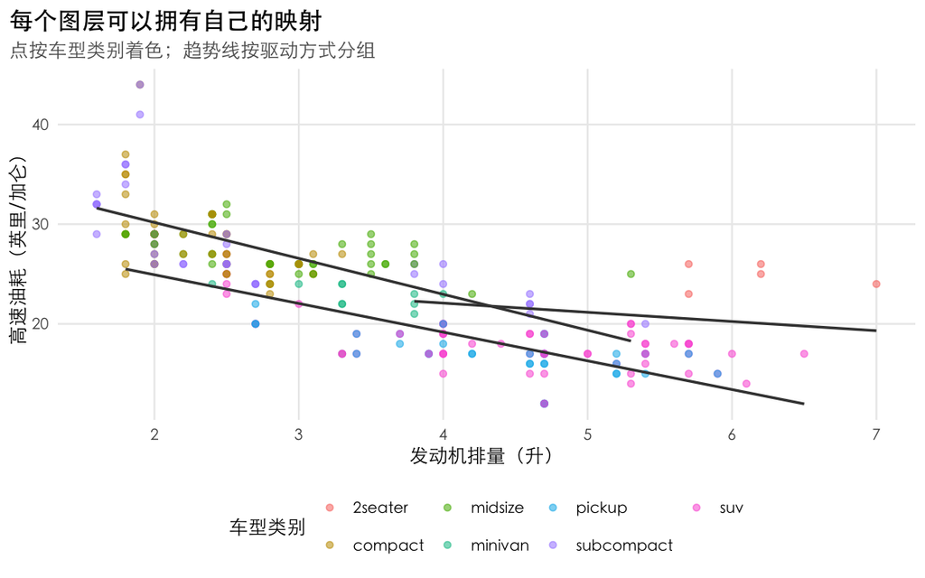

图 3：局部映射允许不同图层使用不同分组。

```r
ggplot(mpg, aes(displ, hwy)) +
  geom_point(aes(color = class), alpha = 0.55) +
  geom_smooth(
    aes(group = drv),
    method = "lm", formula = y ~ x,
    se = FALSE, color = "grey25", linewidth = 0.8,
    show.legend = FALSE
  ) +
  labs(
    title = "每个图层可以拥有自己的映射",
    subtitle = "点按车型类别着色；趋势线按驱动方式分组",
    color = "车型类别",
    x = "发动机排量（升）",
    y = "高速油耗（英里/加仑）"
  )
```

当某层不应该继承全局映射时，可使用 `inherit.aes = FALSE`，并在该层完整指定自己的 `data` 和 `aes()`。

# 3 常用几何对象

## 3.1 散点图：过度重叠、透明度与抖动

离散或取值重复的数据容易重叠。常见对策是减小点、增加透明度，或使用 `geom_jitter()` 轻微扰动位置。

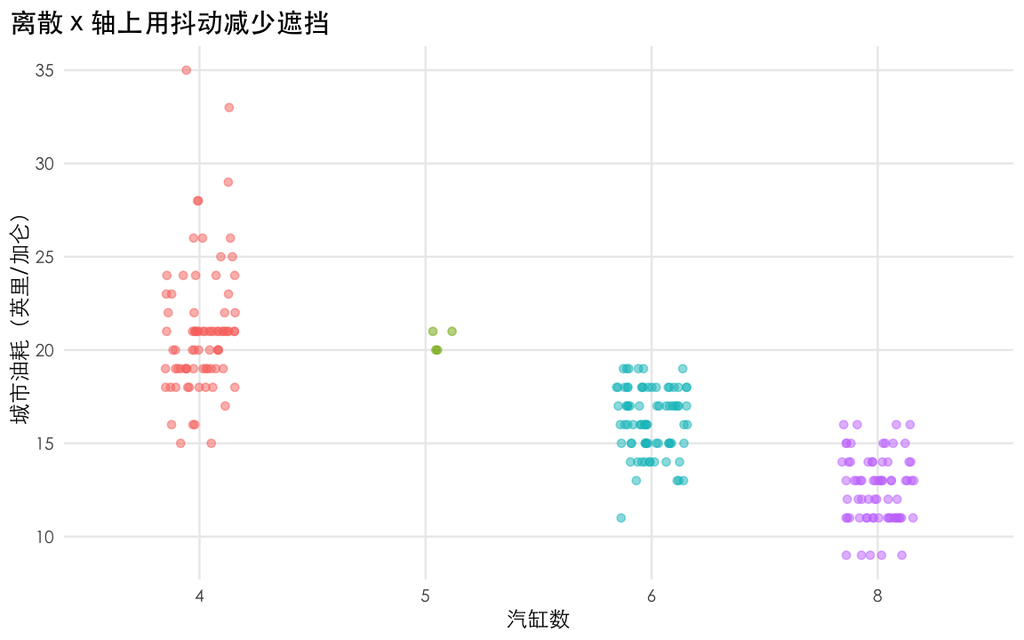

图 4：抖动显示原本重叠的离散观察。

```r
ggplot(mpg, aes(factor(cyl), cty, color = factor(cyl))) +
  geom_jitter(width = 0.16, height = 0, alpha = 0.5, size = 1.8,
              show.legend = FALSE) +
  labs(
    title = "离散 x 轴上用抖动减少遮挡",
    x = "汽缸数",
    y = "城市油耗（英里/加仑）"
  )
```

`geom_jitter()` 适合展示个体观察，但抖动只是显示手段，不应被解释成真实测量误差。大数据还可考虑二维分箱、等高线或抽样。

## 3.2 平滑曲线与回归线

`geom_smooth()` 默认方法会随数据量变化。为保证分析含义明确，最好显式写出方法：

- `method = "lm"`：线性模型；
- `method = "loess"`：局部平滑，适合较小数据；
- `se = TRUE/FALSE`：是否显示置信带；
- `formula = y ~ x`：明确模型公式。

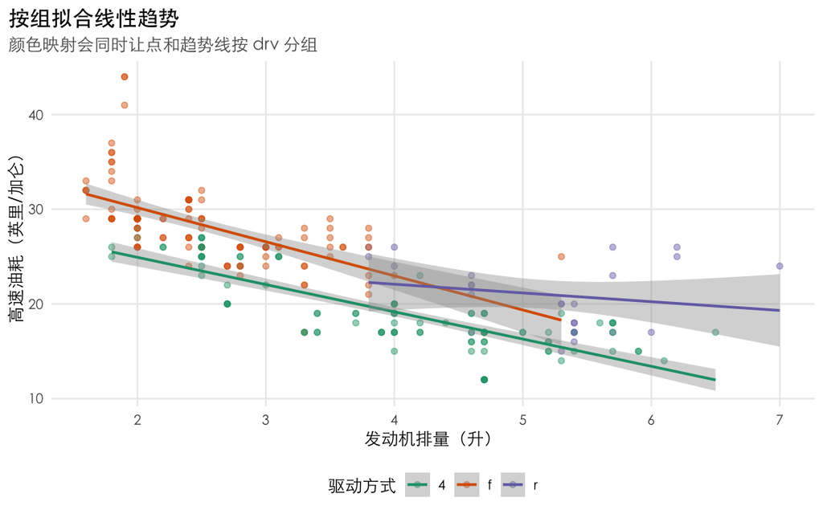

图 5：散点图叠加线性回归线及置信带。

```r
ggplot(mpg, aes(displ, hwy, color = drv)) +
  geom_point(alpha = 0.45) +
  geom_smooth(method = "lm", formula = y ~ x, se = TRUE, linewidth = 0.9) +
  scale_color_brewer(palette = "Dark2") +
  labs(
    title = "按组拟合线性趋势",
    subtitle = "颜色映射会同时让点和趋势线按 drv 分组",
    color = "驱动方式",
    x = "发动机排量（升）",
    y = "高速油耗（英里/加仑）"
  )
```

注意：平滑线描述关联，不自动代表因果关系；外推到数据范围之外尤其危险。

## 3.3 线图与时间序列

`geom_line()` 会按 x 排序后连接点，适合时间序列；`geom_path()` 按数据行顺序连接，适合轨迹。多条线必须有正确的 `group`，而映射 `color`、`linetype` 通常会自动建立分组。

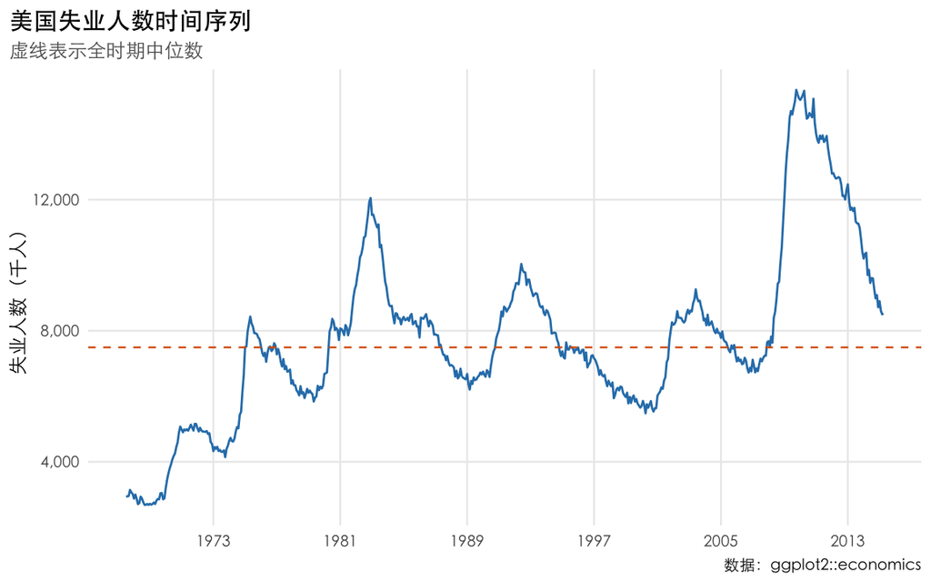

图 6：时间序列与参考线。

```r
unemp_median <- median(economics$unemploy, na.rm = TRUE)

ggplot(economics, aes(date, unemploy)) +
  geom_line(color = "#2c7fb8", linewidth = 0.65) +
  geom_hline(yintercept = unemp_median, linetype = "dashed", color = "#d95f0e") +
  scale_x_date(date_breaks = "8 years", date_labels = "%Y") +
  scale_y_continuous(labels = scales::label_number(big.mark = ",")) +
  labs(
    title = "美国失业人数时间序列",
    subtitle = "虚线表示全时期中位数",
    x = NULL,
    y = "失业人数（千人）",
    caption = "数据：ggplot2::economics"
  )
```

时间变量应是 `Date` 或日期时间类型，而不是普通字符串。多组时间序列还要检查每组内部是否按时间排序。

## 3.4 柱状图：`geom_bar()` 与 `geom_col()`

这两个函数外观相似，数据含义不同：

- `geom_bar()`：只有 x，默认 `stat = "count"`，计算每类行数；
- `geom_col()`：同时提供 x 和 y，直接画已经汇总好的数值。

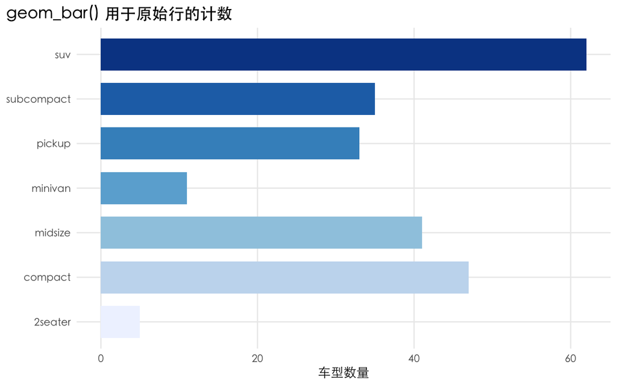

图 7：geom_bar() 自动计算每个车型类别的数量。

```r
ggplot(mpg, aes(y = class, fill = class)) +
  geom_bar(show.legend = FALSE, width = 0.72) +
  scale_fill_brewer(palette = "Blues") +
  labs(
    title = "geom_bar() 用于原始行的计数",
    x = "车型数量",
    y = NULL
  )
```

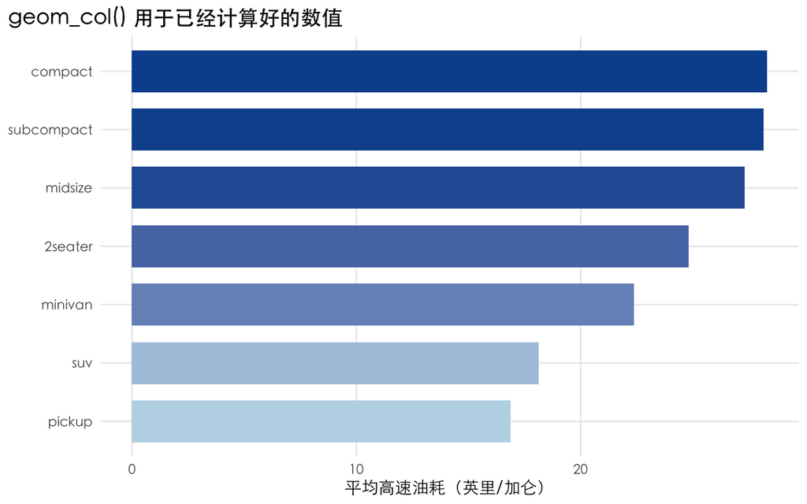

图 8：geom_col() 绘制预先汇总的平均值。

```r
class_mean <- aggregate(hwy ~ class, data = mpg, FUN = mean)
class_mean$class <- reorder(class_mean$class, class_mean$hwy)

ggplot(class_mean, aes(hwy, class, fill = hwy)) +
  geom_col(width = 0.72, show.legend = FALSE) +
  scale_fill_gradient(low = "#bdd7e7", high = "#08519c") +
  labs(
    title = "geom_col() 用于已经计算好的数值",
    x = "平均高速油耗（英里/加仑）",
    y = NULL
  )
```

## 3.5 堆叠、并列与比例

`position` 控制同一 x 类别中的多个组如何摆放：

| position | 作用 | 适合回答 |
| --- | --- | --- |
| `"stack"` | 默认堆叠 | 总量和组成是多少？ |
| `"dodge"` | 并列 | 组间绝对数量如何比较？ |
| `"fill"` | 每柱归一到 100% | 组成比例如何比较？ |
| `"identity"` | 原位置重叠 | 已有坐标或配合透明度 |

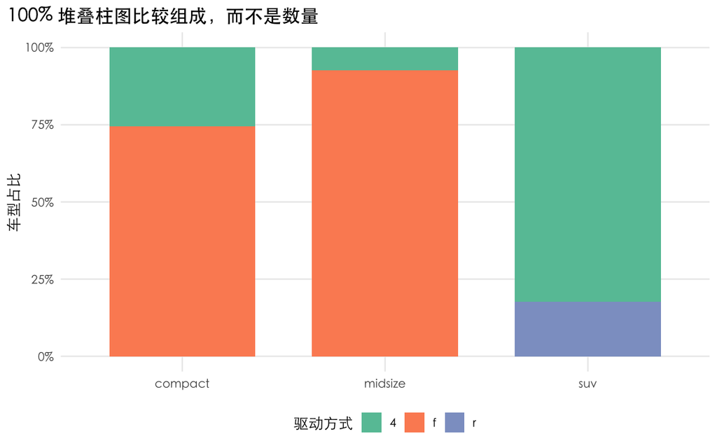

图 9：position = ‘fill’ 比较每类车型的驱动方式构成。

```r
mpg_three <- subset(mpg, class %in% c("compact", "midsize", "suv"))

ggplot(mpg_three, aes(class, fill = drv)) +
  geom_bar(position = "fill", width = 0.72) +
  scale_y_continuous(labels = scales::label_percent()) +
  scale_fill_brewer(palette = "Set2") +
  labs(
    title = "100% 堆叠柱图比较组成，而不是数量",
    x = NULL,
    y = "车型占比",
    fill = "驱动方式"
  )
```

百分比柱会隐藏样本量差异；若每组总数很重要，应同时标注 `n` 或另画数量图。

# 4 分布与统计变换

## 4.1 直方图与密度图

直方图的结论可能随箱宽变化。`bins` 指箱数，`binwidth` 指每箱宽度；分析时应根据测量精度与样本规模尝试多个合理值。下面把直方图转换为密度尺度，再叠加核密度曲线。

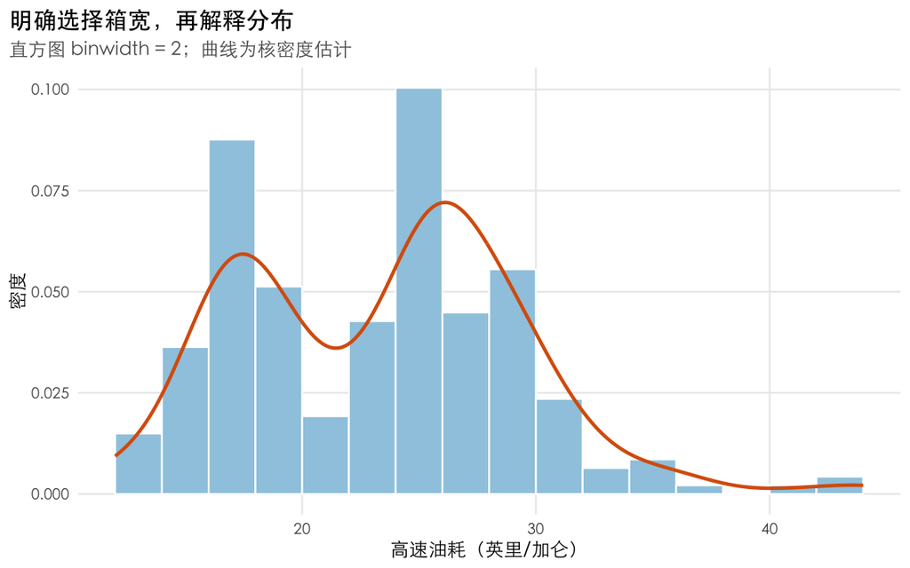

图 10：高速油耗的密度直方图和核密度曲线。

```r
ggplot(mpg, aes(hwy)) +
  geom_histogram(
    aes(y = after_stat(density)),
    binwidth = 2, boundary = 0,
    fill = "#9ecae1", color = "white"
  ) +
  geom_density(color = "#d95f0e", linewidth = 1.05, adjust = 1) +
  labs(
    title = "明确选择箱宽，再解释分布",
    subtitle = "直方图 binwidth = 2；曲线为核密度估计",
    x = "高速油耗（英里/加仑）",
    y = "密度"
  )
```

`after_stat(density)` 引用统计变换产生的变量，是旧写法 `..density..` 的现代替代。

## 4.2 箱线图与小提琴图

箱线图紧凑地显示中位数、四分位距和异常值；小提琴图显示分布形状。叠加使用时，不要让元素互相遮挡。

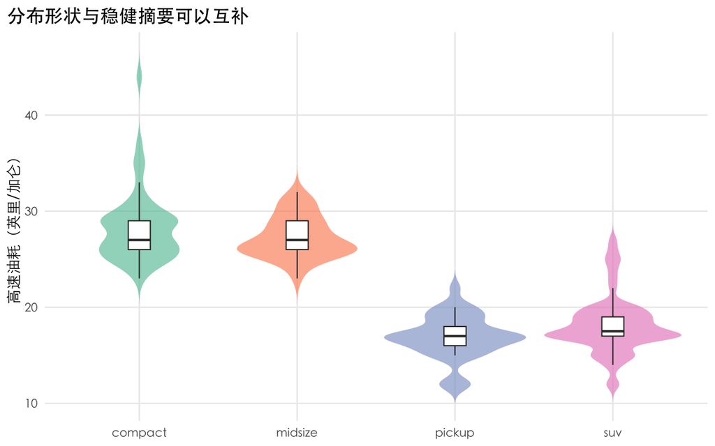

图 11：小提琴图展示形状，窄箱线图展示稳健摘要。

```r
mpg_four <- subset(mpg, class %in% c("compact", "midsize", "pickup", "suv"))

ggplot(mpg_four, aes(class, hwy, fill = class)) +
  geom_violin(trim = FALSE, alpha = 0.65, color = NA, show.legend = FALSE) +
  geom_boxplot(width = 0.14, outlier.shape = NA, fill = "white",
               linewidth = 0.45) +
  scale_fill_brewer(palette = "Set2") +
  labs(
    title = "分布形状与稳健摘要可以互补",
    x = NULL,
    y = "高速油耗（英里/加仑）"
  )
```

小样本的小提琴形状可能不稳定；必要时叠加抖动点并报告每组样本量。

## 4.3 `stat_summary()`：边汇总边作图

`stat_summary()` 可直接按 x 分组计算中心值与区间。下面的点表示均值，误差线表示“均值 ± 1 个标准差”；它不是置信区间，图注应写清定义。

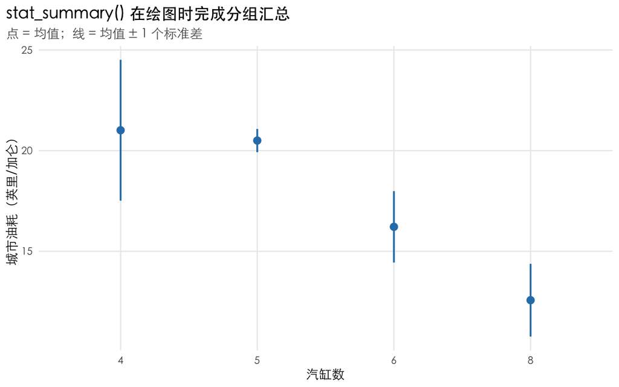

图 12：各汽缸数的城市油耗均值与一个标准差范围。

```r
mean_minus_sd <- function(z) mean(z, na.rm = TRUE) - sd(z, na.rm = TRUE)
mean_plus_sd  <- function(z) mean(z, na.rm = TRUE) + sd(z, na.rm = TRUE)

ggplot(mpg, aes(factor(cyl), cty)) +
  stat_summary(
    fun = mean,
    fun.min = mean_minus_sd,
    fun.max = mean_plus_sd,
    geom = "pointrange",
    color = "#2c7fb8",
    linewidth = 0.8
  ) +
  labs(
    title = "stat_summary() 在绘图时完成分组汇总",
    subtitle = "点 = 均值；线 = 均值 ± 1 个标准差",
    x = "汽缸数",
    y = "城市油耗（英里/加仑）"
  )
```

探索阶段这样很方便；正式分析中，若汇总逻辑复杂，建议先生成明确的汇总数据框，再用 `geom_col()`、`geom_point()` 或 `geom_errorbar()` 作图，便于审计。

# 5 分面：用小多图比较组别

## 5.1 `facet_wrap()` 与 `facet_grid()`

- `facet_wrap(~ var)`：一个分面变量，自动换行；
- `facet_grid(rows ~ cols)`：行列组合有明确语义；
- `scales = "free_y"` 等：允许各面板使用不同标度，但会削弱跨面板的绝对比较。

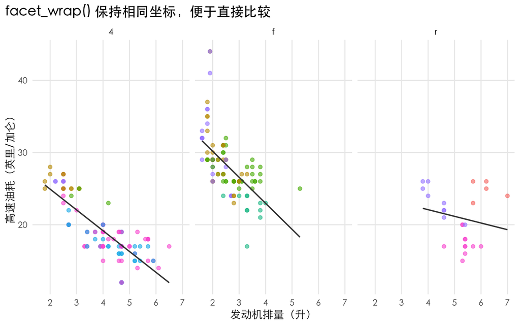

图 13：按驱动方式分面的排量—油耗关系。

```r
ggplot(mpg, aes(displ, hwy)) +
  geom_point(aes(color = class), alpha = 0.6, show.legend = FALSE) +
  geom_smooth(method = "lm", formula = y ~ x, se = FALSE,
              color = "grey25", linewidth = 0.7) +
  facet_wrap(~ drv, nrow = 1) +
  labs(
    title = "facet_wrap() 保持相同坐标，便于直接比较",
    x = "发动机排量（升）",
    y = "高速油耗（英里/加仑）"
  )
```

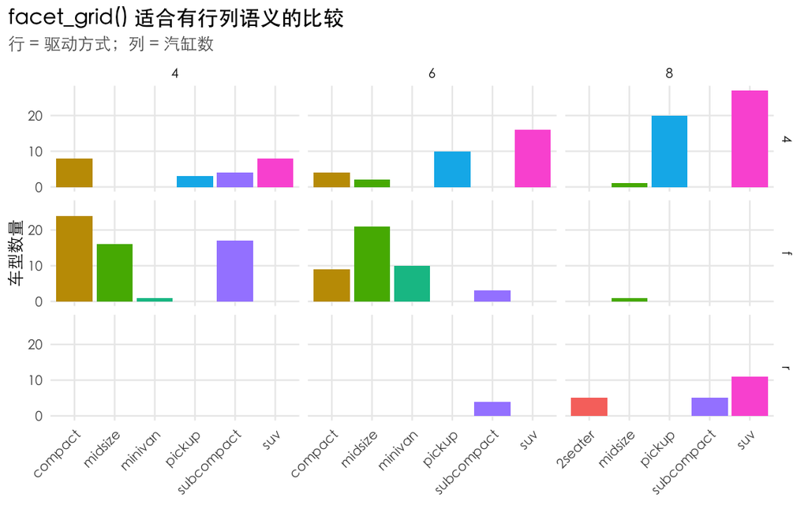

图 14：行列分面同时编码驱动方式和汽缸数。

```r
facet_data <- subset(mpg, cyl %in% c(4, 6, 8))

ggplot(facet_data, aes(class, fill = class)) +
  geom_bar(show.legend = FALSE) +
  facet_grid(drv ~ cyl, scales = "free_x", space = "free_x") +
  labs(
    title = "facet_grid() 适合有行列语义的比较",
    subtitle = "行 = 驱动方式；列 = 汽缸数",
    x = NULL,
    y = "车型数量"
  ) +
  theme(axis.text.x = element_text(angle = 45, hjust = 1))
```

空面板有时是重要信息，说明某些组合不存在；不要只为“好看”就删除它。

# 6 标度：控制数据如何映射到视觉属性

## 6.1 连续、离散与手动标度

标度函数通常采用 `scale_<视觉属性>_<类型>()` 命名，例如：

- `scale_x_continuous()`、`scale_y_log10()`：位置；
- `scale_color_brewer()`、`scale_fill_viridis_d()`：离散颜色；
- `scale_color_viridis_c()`、`scale_fill_gradient()`：连续颜色；
- `scale_color_manual()`：手动指定类别颜色；
- `scale_x_date()`：日期轴。

`color` 通常控制点、线和轮廓；`fill` 控制柱、面积与封闭形状的内部填充。

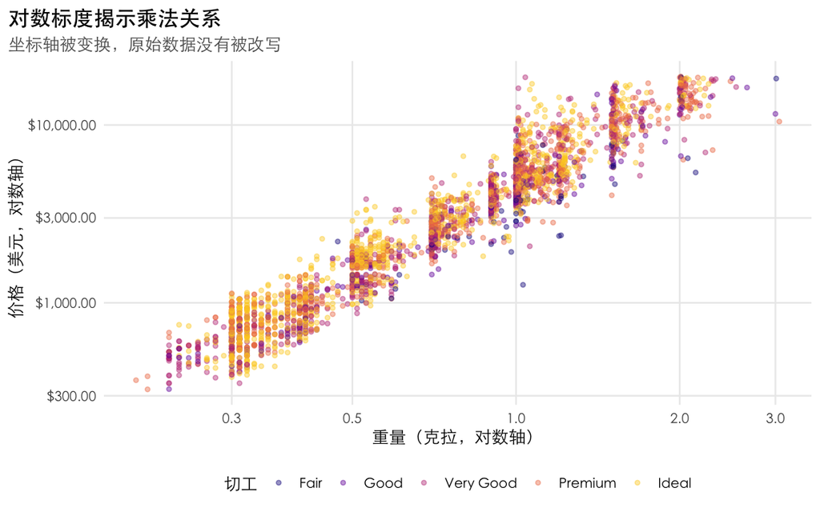

图 15：钻石重量和价格同时使用对数标度。

```r
diamond_sample <- diamonds[sample.int(nrow(diamonds), 3000), ]

ggplot(diamond_sample, aes(carat, price, color = cut)) +
  geom_point(alpha = 0.42, size = 1.2) +
  scale_x_log10(
    breaks = c(0.3, 0.5, 1, 2, 3),
    labels = scales::label_number()
  ) +
  scale_y_log10(labels = scales::label_dollar()) +
  scale_color_viridis_d(option = "C", end = 0.9) +
  labs(
    title = "对数标度揭示乘法关系",
    subtitle = "坐标轴被变换，原始数据没有被改写",
    x = "重量（克拉，对数轴）",
    y = "价格（美元，对数轴）",
    color = "切工"
  )
```

对数轴不能显示零或负值，并会改变视觉距离的含义。轴标题或图注明确说明变换。

## 6.2 手动颜色与类别顺序

手动颜色应使用有名称的向量，使颜色与类别按名称匹配，而不是依赖偶然的因子顺序。

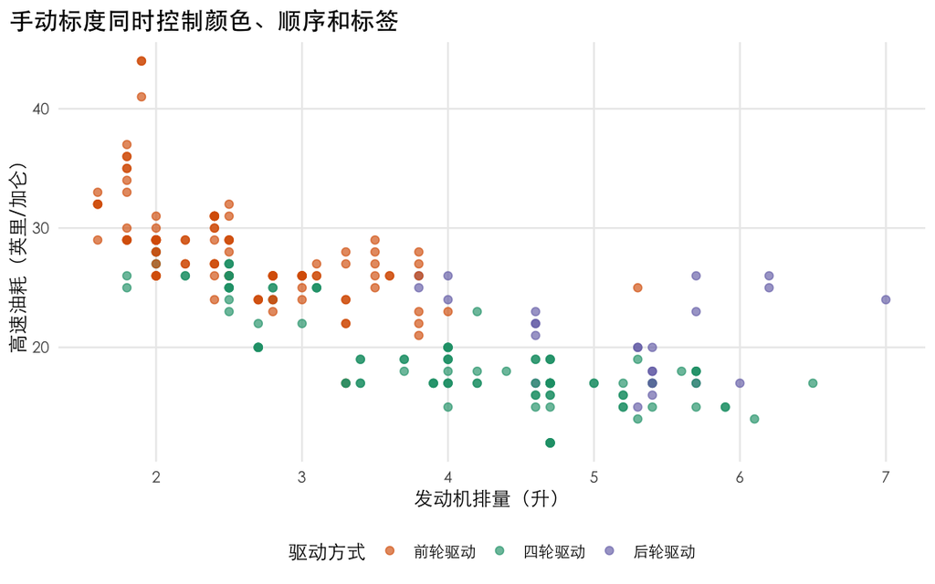

图 16：使用有名称的向量稳定指定类别颜色。

```r
drive_colors <- c("4" = "#1b9e77", "f" = "#d95f02", "r" = "#7570b3")

ggplot(mpg, aes(displ, hwy, color = drv)) +
  geom_point(alpha = 0.65, size = 2) +
  scale_color_manual(
    values = drive_colors,
    breaks = c("f", "4", "r"),
    labels = c("前轮驱动", "四轮驱动", "后轮驱动")
  ) +
  labs(
    title = "手动标度同时控制颜色、顺序和标签",
    x = "发动机排量（升）",
    y = "高速油耗（英里/加仑）",
    color = "驱动方式"
  )
```

类别顺序会影响轴、堆叠和图例。常用 base R 方法包括：

```r
# 指定业务顺序
dat$level <- factor(dat$level, levels = c("低", "中", "高"))

# 按某个数值汇总结果重排
dat$group <- reorder(dat$group, dat$value, FUN = median)
```

## 6.3 `limits` 与视觉缩放的区别

这是一个影响统计结果的重要区别：

```r
# 会在统计计算前删除范围外的数据；平滑线、箱线图等可能改变
p + scale_y_continuous(limits = c(20, 40))

# 只放大显示窗口，不删除数据；适合“镜头缩放”
p + coord_cartesian(ylim = c(20, 40))
```

若只想观察局部区域，优先使用 `coord_cartesian()`。如果确实需要过滤数据，最好在绘图前显式过滤，让分析意图清楚可见。

# 7 坐标系统、标签与注释

## 7.1 坐标系统

- `coord_cartesian()`：缩放窗口而不删除数据；
- `coord_fixed(ratio = 1)`：固定 x、y 单位的物理比例；
- `coord_flip()`：交换横纵轴，仍可读旧代码；新版 ggplot2 通常更推荐直接交换 `aes(x, y)`；
- `coord_polar()`：极坐标，可制作饼图/环图，但角度和面积较难准确比较。

坐标系统作用在标度之后。对需要精确比较的图，位置和长度通常比角度、面积更易读。

## 7.2 标题、标签、参考线与注释

`labs()` 统一管理标题、副标题、坐标轴、图例标题和图注。`annotate()` 添加单个说明；`geom_text()` / `geom_label()` 则从数据框批量添加标签。

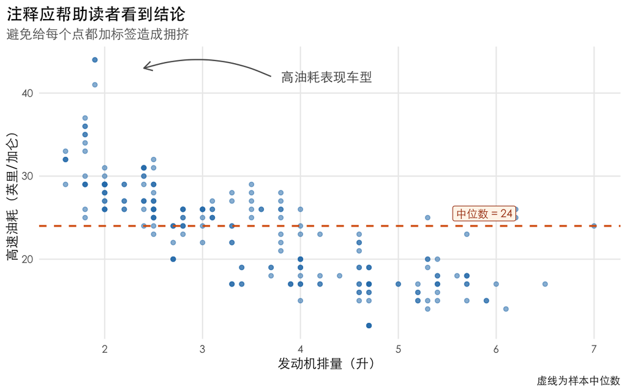

图 17：用参考线和注释突出关键区域。

```r
hwy_median <- median(mpg$hwy)

ggplot(mpg, aes(displ, hwy)) +
  geom_point(color = "#2c7fb8", alpha = 0.55) +
  geom_hline(yintercept = hwy_median, linetype = "dashed",
             color = "#d95f0e", linewidth = 0.8) +
  annotate(
    "label", x = 6.2, y = hwy_median + 1.5,
    label = paste0("中位数 = ", hwy_median),
    hjust = 1, size = 3.5,
    fill = "#fff5eb", color = "#a63603", family = plot_family
  ) +
  annotate(
    "curve", x = 3.7, y = 42, xend = 2.4, yend = 43,
    curvature = 0.2, arrow = arrow(length = grid::unit(0.12, "inches")),
    color = "grey35"
  ) +
  annotate("text", x = 3.8, y = 42, label = "高油耗表现车型",
           hjust = 0, color = "grey25", family = plot_family) +
  labs(
    title = "注释应帮助读者看到结论",
    subtitle = "避免给每个点都加标签造成拥挤",
    x = "发动机排量（升）",
    y = "高速油耗（英里/加仑）",
    caption = "虚线为样本中位数"
  ) +
  coord_cartesian(clip = "off")
```

`unit()` 与 `arrow()` 来自 R 的 `grid` 包；它们随 R 一起安装，无需额外依赖。

# 8 主题、图例与可复用样式

## 8.1 主题控制什么

主题只控制**非数据元素**，不会改变数据映射。常用完整主题有 `theme_minimal()`、`theme_classic()`、`theme_bw()`；`theme()` 用于局部调整：

- `element_text()`：文字；
- `element_line()`：网格线和轴线；
- `element_rect()`：背景和边框；
- `element_blank()`：移除元素。

本教程在 setup 代码块中定义了 `theme_guide()`。项目中把统一样式封装成函数，比在每张图后复制一长串 `theme()` 更可靠。

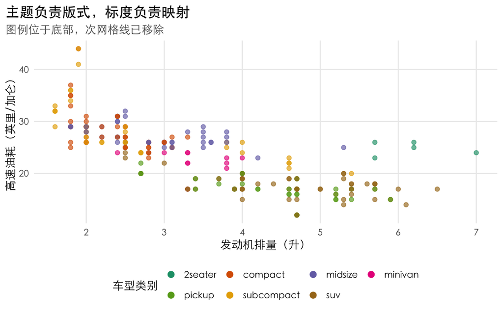

图 18：可复用主题统一字体、网格、标题和图例位置。

```r
ggplot(mpg, aes(displ, hwy, color = class)) +
  geom_point(alpha = 0.65, size = 2) +
  scale_color_brewer(palette = "Dark2") +
  labs(
    title = "主题负责版式，标度负责映射",
    subtitle = "图例位于底部，次网格线已移除",
    x = "发动机排量（升）",
    y = "高速油耗（英里/加仑）",
    color = "车型类别"
  ) +
  guides(color = guide_legend(nrow = 2, byrow = TRUE,
                              override.aes = list(alpha = 1, size = 3))) +
  theme_guide(base_size = 13)
```

若多个图层映射到同一变量，并且标度名称一致，ggplot2 通常会合并图例。可用 `guides()` 调整顺序、行数和图例中的示例标记，或用 `theme(legend.position = "none")` 删除不必要的图例。

# 9 二维汇总：热图

当两个轴都是类别、单元格表示数量或数值时，`geom_tile()` 很实用。

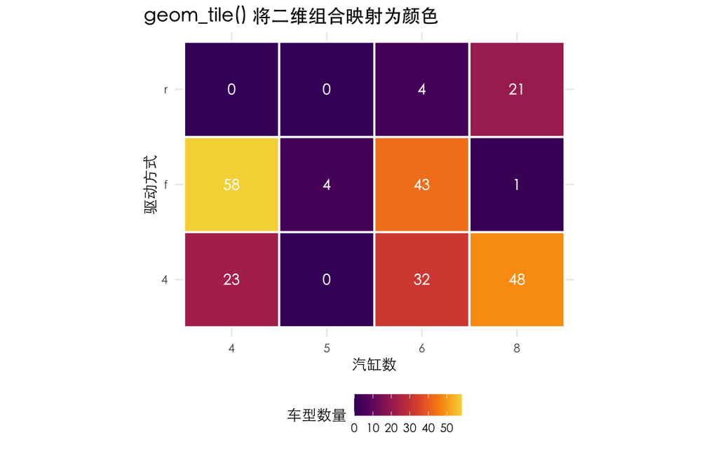

图 19：汽缸数和驱动方式组合的车型数量热图。

```r
heat <- as.data.frame(table(cyl = mpg$cyl, drv = mpg$drv))

ggplot(heat, aes(cyl, drv, fill = Freq)) +
  geom_tile(color = "white", linewidth = 0.8) +
  geom_text(aes(label = Freq), color = "white", fontface = "bold",
            family = plot_family) +
  scale_fill_viridis_c(option = "B", begin = 0.2, end = 0.9) +
  labs(
    title = "geom_tile() 将二维组合映射为颜色",
    x = "汽缸数",
    y = "驱动方式",
    fill = "车型数量"
  ) +
  coord_fixed()
```

连续色板应具有感知上相对均匀的亮度变化。`viridis` 系列通常对色觉差异和灰度打印更友好。若低值单元格文字不清楚，可根据填充值动态切换文字颜色。

# 10 在函数中使用 ggplot2

不要再使用已弃用的 `aes_string()`。在函数中按列名编程，可使用 `.data[[...]]`：

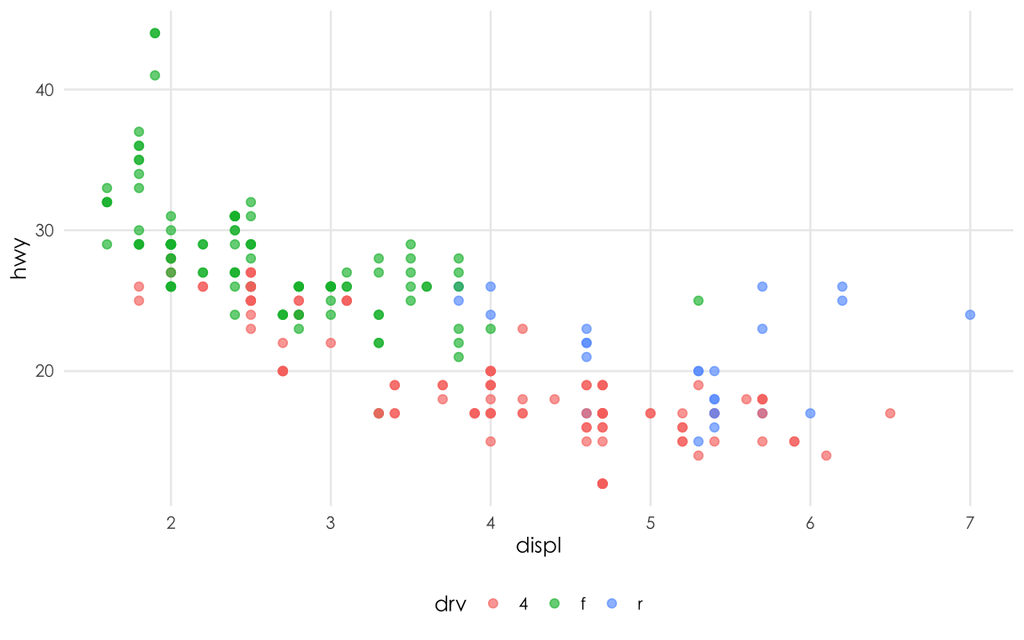

```r
make_scatter <- function(data, x, y, color = NULL) {
  if (is.null(color)) {
    mapping <- aes(x = .data[[x]], y = .data[[y]])
  } else {
    mapping <- aes(
      x = .data[[x]],
      y = .data[[y]],
      color = .data[[color]]
    )
  }

  ggplot(data, mapping) +
    geom_point(alpha = 0.65, size = 2) +
    labs(x = x, y = y, color = color) +
    theme_guide()
}

make_scatter(mpg, "displ", "hwy", "drv")
```

这个函数返回的是 ggplot 对象，所以仍可继续叠加：

```r
make_scatter(mpg, "displ", "hwy", "drv") +
  geom_smooth(method = "lm", formula = y ~ x) +
  labs(title = "函数生成的图仍可继续扩展")
```

# 11 导出高质量图表

`ggsave()` 默认保存最后显示的图；在脚本和函数中，显式传入 `plot` 更安全。宽高与 `dpi` 共同决定栅格图像像素尺寸。

```r
p <- ggplot(mpg, aes(displ, hwy, color = drv)) +
  geom_point(alpha = 0.7) +
  labs(x = "Engine displacement (L)", y = "Highway MPG") +
  theme_guide()

# 适合文档或网页的 PNG：7 × 4.5 英寸，300 dpi
ggsave(
  filename = "mpg_scatter.png",
  plot = p,
  width = 7, height = 4.5, units = "in",
  dpi = 300, bg = "white"
)

# 矢量 PDF 适合论文与后期排版
ggsave("mpg_scatter.pdf", p, width = 7, height = 4.5, units = "in")
```

常见建议：

- 网页：PNG，通常 120–180 dpi 已够用；需要高清打印可用 300 dpi；
- 线条、文字为主：PDF 或 SVG 矢量格式；
- 大量半透明点：PNG 往往比矢量文件更小；
- 保持明确的 `width`、`height`、`units` 和 `bg`，避免不同机器输出不一致；
- 先按最终展示尺寸检查字号，而不是只看 RStudio 的缩放预览。

# 12 常见问题与排错清单

| 现象 | 常见原因 | 处理方法 |
| --- | --- | --- |
| 出现一个写着颜色名的奇怪图例 | 常量写进了 `aes()` | 把 `color = "red"` 放到 `aes()` 外 |
| 柱子全是灰色或颜色没变化 | 混淆 `color` 与 `fill` | 柱/面积内部通常用 `fill` |
| `geom_bar()` 报 y 相关错误 | 已汇总数据仍用了计数柱 | 改用 `geom_col()` |
| 多条线被错误连在一起 | 缺少分组 | 映射 `group`、`color` 或 `linetype` |
| 平滑线或箱线图缩放后改变 | 用 `scale_* (limits=...)` 删除了数据 | 仅缩放时用 `coord_cartesian()` |
| 点太黑、看不出密度 | 过度重叠 | 使用较小点、`alpha`、`jitter`、分箱或抽样 |
| 直方图结论不稳定 | 依赖默认箱数 | 根据领域意义设置并比较 `binwidth` |
| 类别顺序不合逻辑 | 字符/因子使用默认顺序 | 显式 `factor(levels=...)` 或 `reorder()` |
| 图例重复或无法合并 | 不同图层的映射名/标度不同 | 统一映射变量和 `labs(color/fill=...)` |
| 警告 “Removed … rows” | 缺失值、越界值或标度限制 | 查 `is.na()`、数据范围和 `limits` |

不要为了让警告消失就随手加

```
na.rm =
TRUE
```

。先确认缺失值为何存在、是否应删除，以及删除是否会改变结论。

# 13 快速选择指南

| 分析目标 | 首选图层 | 常用补充 |
| --- | --- | --- |
| 两个连续变量的关系 | `geom_point()` | `alpha`、`geom_smooth()` |
| 连续变量随时间变化 | `geom_line()` | `geom_point()`、参考线 |
| 类别频数 | `geom_bar()` | `position`、`coord_flip()` |
| 已汇总的类别数值 | `geom_col()` | 排序、误差线 |
| 单变量分布 | `geom_histogram()` / `geom_density()` | 明确 `binwidth` / `adjust` |
| 多组分布比较 | `geom_boxplot()` / `geom_violin()` | 抖动点、样本量 |
| 两个类别的组合数值 | `geom_tile()` | 连续填充标度、文字标签 |
| 多组重复比较 | `facet_wrap()` / `facet_grid()` | 保持共享标度 |

# 14 一套可靠的作图工作流

1. 先确认分析单位、缺失值、变量类型与合理范围。
2. 用最简单的几何对象画原始数据，先看异常与重叠。
3. 再加入分组、统计汇总或分面；避免一次映射过多视觉属性。
4. 明确选择标度、类别顺序、轴范围与颜色方案。
5. 写出结论型标题、完整轴标签、单位、图例标题和数据来源。
6. 在最终展示尺寸检查可读性、色觉友好性与黑白打印效果。
7. 用 `ggsave()` 固定尺寸和格式，并保留生成图表的代码与会话信息。

# 15 版本与复现信息

本文档使用现代 ggplot2 语法：线宽使用 `linewidth`，统计变量使用 `after_stat()`，编程接口使用 `.data[[...]]`。

```r
cat("R:", R.version.string, "\n")
```

```
#> R: R version 4.6.1 (2026-06-24)
```

```r
cat("ggplot2:", as.character(packageVersion("ggplot2")), "\n")
```

```
#> ggplot2: 4.0.3
```

```r
cat("knitr:", as.character(packageVersion("knitr")), "\n")
```

```
#> knitr: 1.51
```

```r
cat("rmarkdown:", as.character(packageVersion("rmarkdown")), "\n")
```

```
#> rmarkdown: 2.31
```

至此，你已经覆盖了 ggplot2 最常用的图形语法、几何对象、统计变换、位置、分面、标度、坐标、主题、注释、编程与导出方法。实际项目中，优先保证数据含义和比较任务清晰，再追求视觉装饰。